# Analyzing Texts with the text2vec Package

Dmitriy Selivanov

2016-08-22

# Features

**text2vec** provides an efficient framework with a concise API for text analysis and natural language processing (NLP) in R.

This package is efficient because it is carefully written in C++, which also means that text2vec is memory friendly. Some parts, such as training GloVe word embeddings, are fully parallelized using the excellent [RcppParallel](http://rcppcore.github.io/RcppParallel/) package. This means that the word embeddings are computed in parallel on OS X, Linux, Windows, and Solaris (x86) without any additional tuning or tricks. Finally, a streaming API means that users do not have to load all the data into RAM.

This vignette explains how to use text2vec to vectorize text on arbitrary n-grams using either a vocabulary or feature hashing. See the `glove` vignette for an explanation of how to use state-of-the art [GloVe](http://www-nlp.stanford.edu/projects/glove/) word embeddings with this package.

# Text vectorization

Most text mining and NLP modeling use [bag of words](https://en.wikipedia.org/wiki/Bag-of-words_model) or [bag of n-grams](https://en.wikipedia.org/wiki/N-gram) methods. Despite their simplicity, these models usually demonstrate good performance on text categorization and classification tasks. But in contrast to their theoretical simplicity and practical efficiency building bag-of-words models involves technical challenges. This is especially the case in R because of its copy-on-modify semantics.

## Text analysis pipeline

Let’s briefly review some of the steps in a typical text analysis pipeline:

1. The reseacher usually begins by constructing a [document-term matrix](https://en.wikipedia.org/wiki/Document-term_matrix) (DTM) or term-co-occurence matrix (TCM) from input documents. In other words, the first step is to vectorize text by creating a map from words or n-grams to a [vector space](https://en.wikipedia.org/wiki/Vector_space_model).
2. The researcher fits a model to that DTM. These models might include text classification, topic modeling, or word embedding. Fitting the model will include tuning and validating the model.
3. Finally the researcher applies the model to new data.

In this vignette we will primarily discuss the first step. Texts themselves can take up a lot of memory, but vectorized texts usually do not, because they are stored as sparse matrices. Because of R’s copy-on-modify semantics, it is not easy to iteratively grow a DTM. Thus constructing a DTM, even for a small collections of documents, can be a serious bottleneck for analysts and researchers. It involves reading the whole collection of text documents into RAM and processing it as single vector, which can easily increase memory use by a factor of 2 to 4. The text2vec package solves this problem by providing a better way of constructing a document-term matrix.

## Example: Sentiment analysis on IMDB movie review dataset

This package provides the `movie_review` dataset. It consists of 5000 movie reviews, each of which is marked as positive or negative. Also we will use `data.table` package for data wrangling.

```r
library(text2vec)
library(data.table)
data("movie_review")
setDT(movie_review)
setkey(movie_review, id)
set.seed(2016L)
all_ids = movie_review$id
train_ids = sample(all_ids, 4000)
test_ids = setdiff(all_ids, train_ids)
train = movie_review[J(train_ids)]
test = movie_review[J(test_ids)]
```

To represent documents in vector space, we first have to create mappings from terms to term IDS. We call them *terms* instead of *words* because they can be arbitrary n-grams not just single words. We represent a set of documents as a sparse matrix, where each row corresponds to a document and each column corresponds to a term. This can be done in 2 ways: using the vocabulary itself or by [feature hashing](https://en.wikipedia.org/wiki/Feature_hashing).

### Vocabulary-based vectorization

Let’s first create a vocabulary-based DTM. Here we collect unique terms from all documents and mark each of them with a unique ID using the `vocabulary()` function. We use an iterator to create the vocabulary.

```r
it_train = itoken(train$review,
             preprocess_function = tolower,
             tokenizer = word_tokenizer,
             ids = train$id)
vocab = create_vocabulary(it_train)
```

What was done here?

1. First we created iterator over tokens with `itoken()` function (all functions from `create_*` family work with iterators over tokens). `R` users can find this confusing or at least unusual. But please don’t worry - iterator is just a nice abstraction which allows to hide most of details about input and process data in chunks (so be memory friendly). We are pretty sure that `itoken()` will cover 99% of users needs.
2. We built vocabulary with `create_vocabulary()` function.

Alternatively, we could create list of tokens and reuse it in further steps. Each element of the list should represent a document, and each element should be a character vector of tokens.

```r
train_tokens = train$review %>%
  tolower %>%
  word_tokenizer
it_train = itoken(train_tokens, ids = train$id)
vocab = create_vocabulary(it_train)
```

Note that `text2vec` provides a few tokenizer functions (see `?tokenizers`). Actually they are just a simple wrappers for `base::gsub()` funcion and not very fast or flexible. If you need something more smart or fast I suggest to use regular expression engine from `stringi` package. Or use `tokenizers` package which is built on top of `stringi` and usually covers 90% of use cases.

Now that we have a vocabulary, we can construct a document-term matrix.

```r
vectorizer = vocab_vectorizer(vocab)
dtm_train = create_dtm(it_train, vectorizer)
```

Now we have a DTM and can check its dimensions.

```r
dim(dtm_train)
```

```
## [1]  4000 35596
```

```r
identical(rownames(dtm_train), train$id)
```

```
## [1] TRUE
```

As you can see, the DTM has 4000 rows, equal to the number of documents, and 35596 columns, equal to the number of unique terms.

Now we are ready to fit our first model. Here we will use the `glmnet` package to fit a logistic regression model with an L1 penalty and 4 fold cross-validation.

```r
library(glmnet)
NFOLDS = 4
t1 = Sys.time()
fit = cv.glmnet(x = dtm_train, y = train[['sentiment']],
                 family = 'binomial',
                 # L1 penalty
                 alpha = 1,
                 # interested in the area under ROC curve
                 type.measure = "auc",
                 # 5-fold cross-validation
                 nfolds = NFOLDS,
                 # high value is less accurate, but has faster training
                 thresh = 1e-3,
                 # again lower number of iterations for faster training
                 maxit = 1e3)
print(difftime(Sys.time(), t1, units = 'sec'))
```

```
## Time difference of 3.367087 secs
```

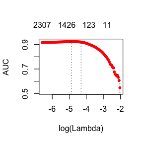

```r
plot(fit)
```

```r
print(paste("max AUC =", round(max(fit$cvm), 4)))
```

```
## [1] "max AUC = 0.923"
```

We have successfully fit a model to our DTM. Now we can check model performance on test data:

```r
# note that most of text2vec functions are pipe friendly!
it_test = test$review %>%
  tolower %>%
  word_tokenizer %>%
  itoken(ids = test$id)

dtm_test = create_dtm(it_test, vectorizer)

preds = predict(fit, dtm_test, type = 'response')[,1]
glmnet:::auc(test$sentiment, preds)
```

```
## [1] 0.916697
```

### Pruning vocabulary

For example we can find words “a,” “the,” and “in” in almost all documents, but they do not provide much useful information. Usually such words are called [stop words](https://en.wikipedia.org/wiki/Stop_words). On the other hand, the corpus also contains very uncommon terms, which are contained in only a few documents. These terms are also useless, because we don’t have sufficient statistics for them. Here we will remove both very common and very unusual terms.

```r
stop_words = c("i", "me", "my", "myself", "we", "our", "ours", "ourselves", "you", "your", "yours")
vocab = create_vocabulary(it_train, stopwords = stop_words)
pruned_vocab = prune_vocabulary(vocab,
                                 term_count_min = 10,
                                 doc_proportion_max = 0.5,
                                 doc_proportion_min = 0.001)
vectorizer = vocab_vectorizer(pruned_vocab)
dtm_train = create_dtm(it_train, vectorizer)
dim(dtm_train)
```

```
## [1] 4000 6585
```

Note that the new DTM has many fewer columns than the original DTM.

### TF-IDF

We can (and usually should) also apply a [TF-IDF](https://en.wikipedia.org/wiki/Tf%E2%80%93idf) transformation to our DTM, which will increase the weight of terms which are specific to a single document or handful of documents and decrease the weight for terms used in most documents:

```r
idf = get_idf(dtm_train)
dtm_train_tfidf = dtm_train %>%
  transform_tfidf(idf)
```

Now, let’s fit our model again.

```r
t1 = Sys.time()
fit_2 = cv.glmnet(x = dtm_train_tfidf, y = train[['sentiment']],
                 family = 'binomial',
                 alpha = 1,
                 type.measure = "auc",
                 nfolds = NFOLDS,
                 thresh = 1e-3,
                 maxit = 1e3)
print(difftime(Sys.time(), t1, units = 'sec'))
```

```
## Time difference of 1.72399 secs
```

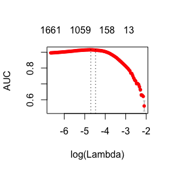

```r
plot(fit_2)
```

```r
print(paste("max AUC =", round(max(fit_2$cvm), 4)))
```

```
## [1] "max AUC = 0.9149"
```

Lets check model performance on test dataset:

```r
dtm_test = create_dtm(it_test, vectorizer)
dtm_test_tfidf = dtm_test %>% transform_tfidf(idf)
preds = predict(fit_2, dtm_test_tfidf, type = 'response')[,1]
glmnet:::auc(test$sentiment, preds)
```

```
## [1] 0.9135409
```

### Can we improve the model?

We can try to improve our model by using n-grams instead of words. We will use up to 3-grams:

```r
t1 = Sys.time()
vocab = create_vocabulary(it_train, ngram = c(1L, 3L))
print(difftime(Sys.time(), t1, units = 'sec'))
```

```
## Time difference of 3.571398 secs
```

```r
vocab = vocab %>% prune_vocabulary(term_count_min = 10,
                   doc_proportion_max = 0.5,
                   doc_proportion_min = 0.001)

vectorizer = vocab_vectorizer(vocab)

t1 = Sys.time()
dtm_train = create_dtm(it_train, vectorizer)
print(difftime(Sys.time(), t1, units = 'sec'))
```

```
## Time difference of 2.031575 secs
```

```r
dim(dtm_train)
```

```
## [1]  4000 22405
```

```r
idf = get_idf(dtm_train)
dtm_train_tfidf = transform_tfidf(dtm_train, idf)

t1 = Sys.time()
fit = cv.glmnet(x = dtm_train_tfidf, y = train[['sentiment']],
                 family = 'binomial',
                 alpha = 1,
                 type.measure = "auc",
                 nfolds = NFOLDS,
                 thresh = 1e-3,
                 maxit = 1e3)
print(difftime(Sys.time(), t1, units = 'sec'))
```

```
## Time difference of 3.248956 secs
```

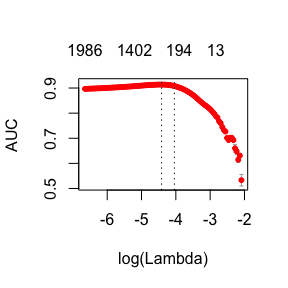

```r
plot(fit)
```

```r
print(paste("max AUC =", round(max(fit$cvm), 4)))
```

```
## [1] "max AUC = 0.9138"
```

### Feature hashing

If you are not familiar with feature hashing (the so-called “hashing trick”) I recommend that you start with the [Wikipedia article](https://en.wikipedia.org/wiki/Feature_hashing), then read the [original paper](http://alex.smola.org/papers/2009/Weinbergeretal09.pdf) by a Yahoo! research team. This techique is very fast because we don’t have to perform a lookup over an associative array. Another benefit is that it leads to a very low memory footprint, since we can map an arbitrary number of features into much more compact space. This method was popularized by Yahoo! and is widely used in [Vowpal Wabbit](https://github.com/JohnLangford/vowpal_wabbit/).

Here is how to use feature hashing in text2vec.

```r
vectorizer = hash_vectorizer(hash_size = 2 ^ 16, ngram = c(1L, 3L))

t1 = Sys.time()
dtm_train = create_dtm(it_train, vectorizer)
print(difftime(Sys.time(), t1, units = 'sec'))
```

```
## Time difference of 2.800798 secs
```

```r
idf = get_idf(dtm_train)
dtm_train = dtm_train %>%
  transform_tfidf(idf)

t1 = Sys.time()
fit = cv.glmnet(x = dtm_train, y = train[['sentiment']],
                 family = 'binomial',
                 alpha = 1,
                 type.measure = "auc",
                 nfolds = 5,
                 thresh = 1e-3,
                 maxit = 1e3)
print(difftime(Sys.time(), t1, units = 'sec'))
```

```
## Time difference of 8.088212 secs
```

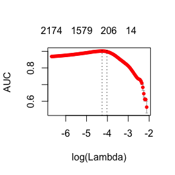

```r
plot(fit)
```

```r
print(paste("max AUC =", round(max(fit$cvm), 4)))
```

```
## [1] "max AUC = 0.9012"
```

```r
dtm_test = create_dtm(it_test, vectorizer) %>%
  transform_tfidf(idf)

preds = predict(fit, dtm_test , type = 'response')[, 1]
glmnet:::auc(test$sentiment, preds)
```

```
## [1] 0.8999364
```

As you can see, we our AUC is a bit worse, but DTM construction time was considerably lower. On large collections of documents this can be a significant advantage.